# ENewsExpress15_0_37363400_1784983022

## Problem Statement

### Business Context

The advent of e-news, or electronic news, portals has offered us a great opportunity to quickly get updates on the day-to-day events occurring globally. The information on these portals is retrieved electronically from online databases, processed using a variety of software, and then transmitted to the users. There are multiple advantages of transmitting news electronically, like faster access to the content and the ability to utilize different technologies such as audio, graphics, video, and other interactive elements that are either not being used or aren’t common yet in traditional newspapers.

E-news Express, an online news portal, aims to expand its business by acquiring new subscribers. With every visitor to the website taking certain actions based on their interest, the company plans to analyze these actions to understand user interests and determine how to drive better engagement. The executives at E-news Express believe that there has been a decline in new monthly subscribers compared to the past year because the current webpage is not designed well enough in terms of the outline & recommended content to keep customers engaged long enough to decide to subscribe.

[Companies often analyze user responses to two variants of a product to decide which of the two variants is more effective. This experimental technique, known as A/B testing, is used to determine whether a new feature attracts users based on a chosen metric.]

### Objective

The design team of the company has researched and created a new landing page that has a new outline & more relevant content compared to the old page. To test the effectiveness of the new landing page in gathering new subscribers, the Data Science team experimented by randomly selecting 100 users and dividing them equally into two groups. The existing landing page was served to the first group (control group) and the new landing page to the second group (treatment group). Data regarding the interaction of users in both groups with the two versions of the landing page was collected.

Being a data scientist in E-news Express, you have been asked to explore the data and perform a statistical analysis (at a significance level of 5%) to determine the effectiveness of the new landing page in gathering new subscribers for the news portal by answering the following questions:

- Do the users spend more time on the new landing page than on the existing landing page?
- Is the conversion rate (the proportion of users who visit the landing page and get converted) for the new page greater than the conversion rate for the old page?
- Does the converted status depend on the preferred language?
- Is the time spent on the new page the same for the different language users?

## Import the necessary libraries

```python
import numpy as np
import pandas as pd

# Libraries to help with data visualization
import matplotlib.pyplot as plt
import seaborn as sns
%matplotlib inline

# Library to help with statistical analysis
import scipy.stats as stats
```

## Loading Data Set

```python
#mounting google drive
from google.colab import drive
drive.mount('/content/drive')
```

```python
enews_data = pd.read_csv("/content/drive/MyDrive/Santhosh-Notebooks/Statistics/abtest.csv")
```

```python
# copying data to another variable to avoid any changes to original data
df = enews_data.copy()
```

## Data Overview

```python
df.shape
```

```
(100, 6)
```

```python
df.head()
```

|  | user_id | group | landing_page | time_spent_on_the_page | converted | language_preferred |
| --- | --- | --- | --- | --- | --- | --- |
| 0 | 546592 | control | old | 3.48 | no | Spanish |
| 1 | 546468 | treatment | new | 7.13 | yes | English |
| 2 | 546462 | treatment | new | 4.40 | no | Spanish |
| 3 | 546567 | control | old | 3.02 | no | French |
| 4 | 546459 | treatment | new | 4.75 | yes | Spanish |

```python
df. tail()
```

|  | user_id | group | landing_page | time_spent_on_the_page | converted | language_preferred |
| --- | --- | --- | --- | --- | --- | --- |
| 95 | 546446 | treatment | new | 5.15 | no | Spanish |
| 96 | 546544 | control | old | 6.52 | yes | English |
| 97 | 546472 | treatment | new | 7.07 | yes | Spanish |
| 98 | 546481 | treatment | new | 6.20 | yes | Spanish |
| 99 | 546483 | treatment | new | 5.86 | yes | English |

```python
df.isnull().sum()
```

|  | 0 |
| --- | --- |
| user_id | 0 |
| group | 0 |
| landing_page | 0 |
| time_spent_on_the_page | 0 |
| converted | 0 |
| language_preferred | 0 |

**dtype:** int64

```python
df.duplicated().sum()
```

```
np.int64(0)
```

```python
df.info()
```

```
<class 'pandas.core.frame.DataFrame'>
RangeIndex: 100 entries, 0 to 99
Data columns (total 6 columns):
 #   Column                  Non-Null Count  Dtype
---  ------                  --------------  -----
 0   user_id                 100 non-null    int64
 1   group                   100 non-null    object
 2   landing_page            100 non-null    object
 3   time_spent_on_the_page  100 non-null    float64
 4   converted               100 non-null    object
 5   language_preferred      100 non-null    object
dtypes: float64(1), int64(1), object(4)
memory usage: 4.8+ KB
```

**Observations**

- The dataset has 100 rows and 6 columns, matching the experiment design of 100 randomly selected users.
- A look at the first and last few rows confirms the data has loaded correctly, and the group–page pairing looks consistent: control users see the old page and treatment users see the new page.
- There are no missing values in any of the 6 columns, so no imputation or row removal is needed.
- There are no duplicate rows, so each record represents a unique user. *Data types are as expected: user_id is int64, time_spent_on_the_page is float64, and the remaining 4 columns (group, landing_page, converted, language_preferred) are object (categorical) — no type conversions are required.
- time_spent_on_the_page is the only meaningful numerical variable.
- user_id is only an identifier — its summary statistics carry no analytical meaning, so it can be dropped (or ignored) for the rest of the analysis.

### Observations — Statistical Summary of Time Spent on the Page

```python
df.drop(columns="user_id").describe()
```

|  | time_spent_on_the_page |
| --- | --- |
| count | 100.000000 |
| mean | 5.377800 |
| std | 2.378166 |
| min | 0.190000 |
| 25% | 3.880000 |
| 50% | 5.415000 |
| 75% | 7.022500 |
| max | 10.710000 |

- The average time spent on the landing page is ~5.38 minutes, with a standard deviation of ~2.38 minutes.
- Time spent ranges from 0.19 minutes to 10.71 minutes — so some users leave almost immediately while others stay for over 10 minutes.
- The median (5.415 minutes) is nearly equal to the mean (5.378 minutes), indicating the distribution is approximately symmetric.

### Observations — Summary of Categorical Variables

```python
df.describe(include="object").T
```

|  | count | unique | top | freq |
| --- | --- | --- | --- | --- |
| group | 100 | 2 | control | 50 |
| landing_page | 100 | 2 | old | 50 |
| converted | 100 | 2 | yes | 54 |
| language_preferred | 100 | 3 | Spanish | 34 |

- group has 2 unique values (control, treatment) with a perfect 50–50 split, confirming users were divided equally between the two groups as per the experiment design.
- landing_page also has 2 unique values (old, new) split 50–50, consistent with the group assignment — control → old page, treatment → new page.
- converted has 2 unique values (yes, no). The most frequent value is "yes" with 54 users, meaning the overall conversion rate across both pages combined is 54%. Whether this differs between the old and new page is exactly what we'll test in the bivariate analysis and hypothesis testing.
- language_preferred has 3 unique values . Spanish is the most common with 34 users, which suggests the three languages are fairly evenly distributed

## Univariate Analysis

### Categorical Values

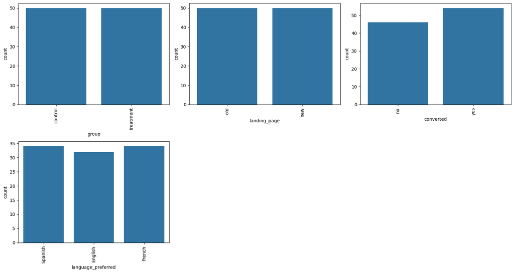

```python
plt.figure(figsize=(16, 12))

# defining the list of numerical features to plot
categorical_features = ['group','landing_page','converted','language_preferred']

# plotting the histogram for each numerical feature
for i, feature in enumerate(categorical_features):
    plt.subplot(3, 3, i+1)    # assign a subplot in the main plot
    sns.countplot(data=df, x=feature)    # plot the histogram
    plt.xticks(rotation=90)    # rotate the x-axis labels for better readability

plt.tight_layout();   # to add spacing between plots
```

**Observations — Univariate Analysis of Categorical Variables**

- group: Users are equally split between control and treatment (50 each), confirming the randomized 50–50 experiment design.
- landing_page: Similarly, 50 users saw the old page and 50 saw the new page, consistent with the group assignment.
- converted: 54 users converted to subscribers while 46 did not — an overall conversion rate of 54%. The split between the old and new page will be examined in the bivariate analysis.
- language_preferred: The three languages are almost evenly distributed — Spanish (34), French (34), and English (32). No single language dominates, which means comparisons across languages (Questions 3 and 4) won't be affected by a heavily imbalanced sample.

Overall, the balanced nature of the data across groups, pages, and languages makes it well-suited for the upcoming hypothesis tests.

### Numerical Values

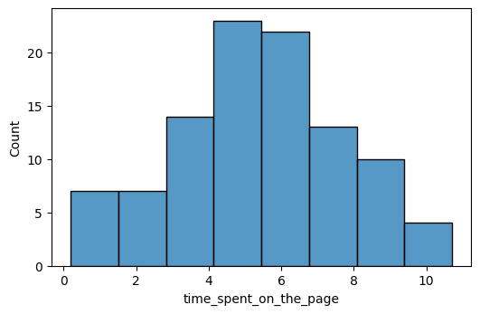

```python
plt.figure(figsize=(15, 10))

# defining the list of numerical features to plot
num_features = ['time_spent_on_the_page']

# plotting the histogram for each numerical feature
for i, feature in enumerate(num_features):
    plt.subplot(3, 3, i+1)    # assign a subplot in the main plot
    sns.histplot(data=df, x=feature)    # plot the histogram

plt.tight_layout();   # to add spacing between plots
```

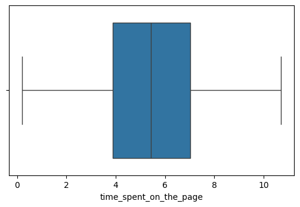

```python
plt.figure(figsize=(15, 10))

# defining the list of numerical features to plot
num_features = ['time_spent_on_the_page']

# plotting the histogram for each numerical feature
for i, feature in enumerate(num_features):
    plt.subplot(3, 3, i+1)    # assign a subplot in the main plot
    sns.boxplot(data=df, x=feature)    # plot the histogram

plt.tight_layout();   # to add spacing between plots
```

Observations — Distribution of Time Spent on the Page

- The distribution of time_spent_on_the_page is approximately symmetric and bell-shaped, with the peak (mode) around 4–6 minutes consistent with the approx mean (5.38) and median (5.42) being nearly equal.
- Most users spend between roughly 3 and 7 minutes on the page, with fewer users at the extremes (under 1 minute or over 9 minutes).
- The boxplot shows no outliers — all values fall within the whiskers, ranging from about 0.19 to 10.71 minutes.
- The box (IQR) is fairly evenly split around the median, further confirming there is no significant skewness in the distribution.
- The roughly normal shape of this distribution is a good sign for the upcoming hypothesis tests (t-test and ANOVA), which assume approximate normality of the underlying data.

## Bivariate Analysis

### Time spent vs Landing page

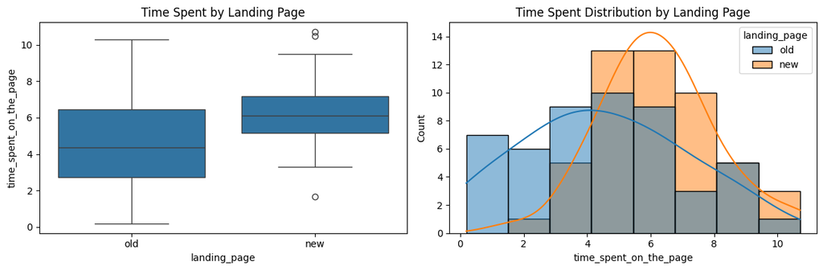

```python
fig, axes = plt.subplots(1, 2, figsize=(12, 4))
sns.boxplot(data=df, x="landing_page", y="time_spent_on_the_page", ax=axes[0])
axes[0].set_title("Time Spent by Landing Page")
sns.histplot(data=df, x="time_spent_on_the_page", hue="landing_page",
             kde=True, ax=axes[1])
axes[1].set_title("Time Spent Distribution by Landing Page")
plt.tight_layout()
plt.show()
```

### Landing Page vs Conversion

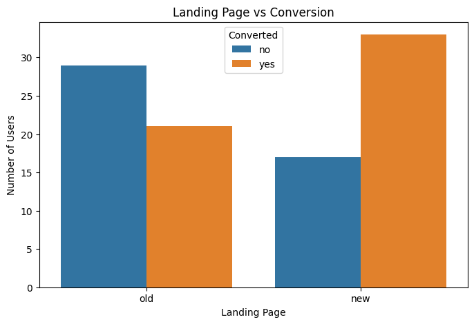

```python
plt.figure(figsize=(8,5))

sns.countplot(
    data=df,
    x="landing_page",
    hue="converted"
)

plt.title("Landing Page vs Conversion")
plt.xlabel("Landing Page")
plt.ylabel("Number of Users")
plt.legend(title="Converted")
plt.show()
```

- On the old page, non-converters outnumber converters: 21 of 50 users converted (42%) while 29 did not.
- On the new page, the pattern flips: 33 of 50 users converted (66%) while only 17 did not.
- The conversion rate for the new page (66%) appears substantially higher than for the old page (42%) — a difference of 24 percentage points.
- This also explains the overall 54% conversion rate we saw in the univariate analysis: it's the average of a weaker old page (42%) and a stronger new page (66%).
- Combined with the earlier finding that users spend more time on the new page, this suggests higher engagement on the new page may be translating into more subscriptions — supporting the design team's hypothesis.
- However, this is based on 50 users per page, so we will formally verify **whether this difference is statistically significant using a one-tailed two-proportion z-test**

## Conversion Percentage by Language

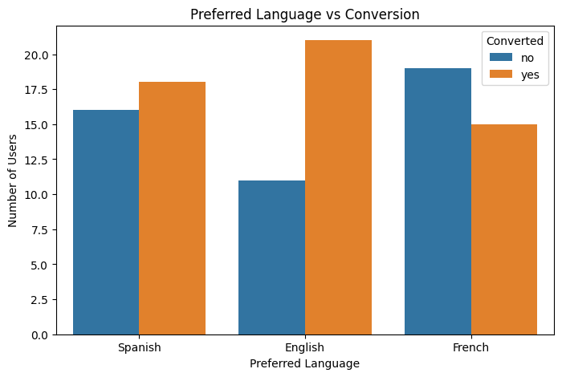

```python
plt.figure(figsize=(8,5))

sns.countplot(
    data=df,
    x="language_preferred",
    hue="converted"
)

plt.title("Preferred Language vs Conversion")
plt.xlabel("Preferred Language")
plt.ylabel("Number of Users")
plt.legend(title="Converted")
plt.show()
```

```python
pd.crosstab(
    df["language_preferred"],
    df["converted"],
    normalize="index"
) * 100
```

| converted language_preferred | no | yes |
| --- | --- | --- |
| English | 34.375000 | 65.625000 |
| French | 55.882353 | 44.117647 |
| Spanish | 47.058824 | 52.941176 |

- Conversion rates differ noticeably across the three languages: English users convert at ~65.6% (21 of 32), Spanish users at ~52.9% (18 of 34), and French users at ~44.1% (15 of 34).
- English is the only language where converters clearly outnumber non-converters; for French, the pattern reverses — more users did not convert (19) than did (15).
- Spanish sits in the middle, with conversions slightly ahead of non-conversions (18 vs 16).
- The gap between the highest (English, ~66%) and lowest (French, ~44%) conversion rates is about 21 percentage points, which suggests converted status might depend on preferred language.
- However, with only ~32–34 users per language, these differences could easily arise from sampling variation — we will formally test whether conversion **depends on language using a chi-square test of independence in Question 3.**

### Preferred Language vs Time Spent (New Landing Page)

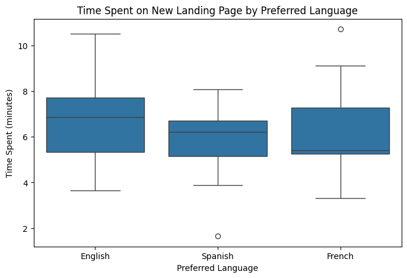

```python
#filtering out information only for new page
new_page = df[df["landing_page"] == "new"]

plt.figure(figsize=(8,5))

sns.boxplot(
    data=new_page,
    x="language_preferred",
    y="time_spent_on_the_page"
)

plt.title("Time Spent on New Landing Page by Preferred Language")
plt.xlabel("Preferred Language")
plt.ylabel("Time Spent (minutes)")
plt.show()
```

```python
new_page.groupby("language_preferred")["time_spent_on_the_page"].describe()
```

| language_preferred | count | mean | std | min | 25% | 50% | 75% | max |
| --- | --- | --- | --- | --- | --- | --- | --- | --- |
| English | 16.0 | 6.663750 | 1.984150 | 3.65 | 5.3275 | 6.865 | 7.7125 | 10.50 |
| French | 17.0 | 6.196471 | 1.933394 | 3.30 | 5.2500 | 5.420 | 7.2700 | 10.71 |
| Spanish | 17.0 | 5.835294 | 1.525656 | 1.65 | 5.1500 | 6.200 | 6.7000 | 8.08 |

- Mean time spent on the new page is fairly similar across languages: English 6.66 minutes, French 6.20 minutes, Spanish 5.84 minutes — a spread of less than a minute between the highest and lowest.
- The medians tell a slightly different ordering (English 6.87, Spanish 6.20, French 5.42), and the boxplots show substantially overlapping IQRs for all three languages — no group stands clearly apart.
- English users show the widest spread (std 1.98) while Spanish users are the most consistent (std 1.53); Spanish also has one low outlier (1.65 minutes) and French one high outlier (10.71 minutes).
- The three language groups are of nearly equal size on the new page (English 16, French 17, Spanish 17), making the comparison fair.
- Overall, time spent on the new page appears roughly similar across the three languages, though English users spend slightly more time on average. Whether these small differences are statistically meaningful will be tested using a one-way ANOVA in Question 4 (with normality and equal-variance checks beforehand).

## Conclusion of EDA — Key Observations

### Data quality and experiment design

- The dataset contains 100 users and 6 variables with no missing values and no duplicates, and all data types are appropriate — no cleaning or preprocessing was required.
- The experiment design is clean and balanced: 50 control users (old page) and 50 treatment users (new page), with the three preferred languages nearly equally represented (Spanish 34, French 34, English 32). This randomized, balanced design makes group comparisons fair and reliable.

### Individual variables

- Time spend: Users spend an average of ~5.38 minutes on the landing page. The distribution is symmetric and bell-shaped (median 5.42 ≈ mean 5.38) with no outliers, ranging from 0.19 to 10.71 minutes.
- Converted: The overall conversion rate across both pages is 54% (54 converted, 46 not) — a fairly even split, which is useful because it means neither outcome is rare and the proportion tests will be reliable.
- Group and Landing page :Both split exactly 50–50, confirming users were divided equally into control (old page) and treatment (new page) as intended. These two variables are effectively redundant by design — control always maps to old, treatment to new.
- Preferred language:The three languages are nearly evenly distributed — Spanish (34), French (34), English (32) — so no single language group dominates, and cross-language comparisons (Q3, Q4) rest on balanced, comparably sized groups.

### Relationships between variables

- New page drives higher engagement: Users spend clearly more time on the new page (median 6.1 min) than the old page (median 4.4 min). Engagement on the new page is also more consistent — the quick exits (< 2 minutes) common on the old page are almost absent on the new page.
- New page drives higher conversion: The conversion rate on the new page (66%) is 24 percentage points higher than on the old page (42%), suggesting the improved engagement is translating into more subscriptions.
- Conversion may vary by language: Conversion rates are 65.6% for English, 52.9% for Spanish, and 44.1% for French users — a spread that might indicate dependence on language, though with only ~33 users per group it could be sampling variation.
- Time on the new page is similar across languages: Mean time spent is comparable for English (6.66), French (6.20), and Spanish (5.84) users, with heavily overlapping distributions.

## Way Forward

The EDA strongly suggests the new landing page outperforms the old one on both engagement and conversion, while language-related differences are less clear-cut. However, these patterns come from a sample of just 100 users, so the observed differences could be due to random chance.

*In the next section, we formally test each of these findings with hypothesis tests at a 5% significance level: a two-sample t-test (time spent), a two-proportion z-test (conversion rate), a chi-square test of independence (conversion vs language), and a one-way ANOVA (time on the new page across languages).*

## Q1 . Do the users spend more time on the new landing page than the old landing page?

### Visual Analysis

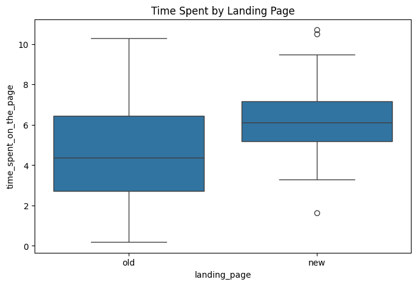

| landing_page | count | mean | std | min | 25% | 50% | 75% | max |
| --- | --- | --- | --- | --- | --- | --- | --- | --- |
| new | 50.0 | 6.2232 | 1.817031 | 1.65 | 5.175 | 6.105 | 7.1600 | 10.71 |
| old | 50.0 | 4.5324 | 2.581975 | 0.19 | 2.720 | 4.380 | 6.4425 | 10.30 |

```python
plt.figure(figsize=(8,5))
sns.boxplot(data=df, x="landing_page", y="time_spent_on_the_page")
plt.title("Time Spent by Landing Page")
plt.show()

df.groupby("landing_page")["time_spent_on_the_page"].describe()
```

**Observation**

The new page's median (6.1 min) is clearly above the old page's (4.4 min), and its entire IQR sits above the old page's median — visually suggesting higher time spent on the new page. A formal test will confirm whether this is statistically significant.

### Formulating null hypothesis

Let u1 = mean time spent on the new page, u2 = mean time spent on the old page.

- H0: u1 ≤ u2 (users do not spend more time on the new page)
- H1: u1 > u2 (users spend more time on the new page)

This is a one-tailed test, since the question asks specifically about more time, not just a difference.

### Test Selection

An Independent Two-Sample t-test is appropriate because:

- The response variable, time_spent_on_the_page, is continuous scale
- The explanatory variable, landing_page, is categorical with two independent groups (old and new).
- The objective is to compare the mean time spent between the two groups.
- The population standard deviations are unknown. The business question is directional ("more time"), making a one-tailed t-test appropriate.

### Let's test whether the t-test assumptions are satisfied or not

- Continuous data — Time spent on the page is measured in minutes, which is Continuous data
- Normally distributed populations or sample sizes > 30 — Each group has 50 observations (> 30), so by the Central Limit Theorem the distribution of sample means will be approximately normal. This is further supported by the univariate analysis, where time spent showed a symmetric, bell-shaped distribution with no outliers.
- Independent populations — The two samples come from two different groups of users (control saw the old page, treatment saw the new page), with no user appearing in both, so the populations are independent.
- Unknown population standard deviations σ₁ and σ₂ — We only have the sample standard deviations, not the population values. This is precisely why we use a t-test rather than a z-test.
- Random sampling from the population — We are informed that the 100 users were randomly selected and randomly assigned to the two groups.

### Data collection and preparation

```python
time_new = df[df["landing_page"] == "new"]["time_spent_on_the_page"]
time_old = df[df["landing_page"] == "old"]["time_spent_on_the_page"]

print("New page - n:", len(time_new), "mean:", round(time_new.mean(), 2))
print("Old page - n:", len(time_old), "mean:", round(time_old.mean(), 2))
```

```
New page - n: 50 mean: 6.22
Old page - n: 50 mean: 4.53
```

### Let's find the p-value

```python
# Two-sample independent t-test (one-tailed: new > old)

test_stat, p_value = stats.ttest_ind(
    time_new, time_old,
    equal_var=False, # Since the sample standard deviations differ noticeably between the two groups (1.82 vs 2.58), we do not assume equal population variances and set equal_var=False
    alternative="greater"
)

print("Test statistic =", round(test_stat, 4))
print("p-value =", round(p_value, 8))
```

```
Test statistic = 3.7868
p-value = 0.00013924
```

### Compare the p-value with alpha

```python
alpha = 0.05

if p_value < alpha:
    print(f"As the p-value {p_value} is less than the level of significance {alpha}, we reject the null hypothesis.")
else:
    print(f"As the p-value {p_value} is greater than the level of significance {alpha}, we fail to reject the null hypothesis.")
```

```
As the p-value 0.0001392381225166549 is less than the level of significance 0.05, we reject the null hypothesis.
```

### Conclusion

The test statistic is 3.7868 and the p-value is 0.00013924. Since the p-value (0.00014) is much less than the level of significance (0.05), we reject the null hypothesis. We have sufficient statistical evidence at a 5% significance level to conclude that users spend more time on the new landing page than on the old landing page.

### Business implication

Users spend on average 6.22 minutes on the new page versus 4.53 minutes on the old page — about 1.7 minutes (≈37%) more. This statistically confirms the design team's expectation that the new outline and more relevant content hold users' attention longer, keeping them engaged long enough to consider subscribing.

## Q2 Is the conversion rate (the proportion of users who visit the landing page and get converted) for the new page greater than the conversion rate for the old page?

### Visual Analysis

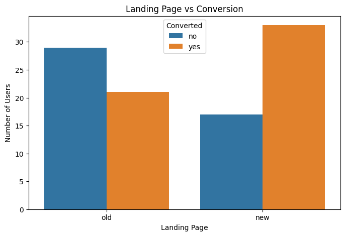

| converted landing_page | no | yes |
| --- | --- | --- |
| new | 34.0 | 66.0 |
| old | 58.0 | 42.0 |

```python
plt.figure(figsize=(8,5))
sns.countplot(data=df, x="landing_page", hue="converted")
plt.title("Landing Page vs Conversion")
plt.xlabel("Landing Page")
plt.ylabel("Number of Users")
plt.legend(title="Converted")
plt.show()

# Conversion rate (%) per page
pd.crosstab(df["landing_page"], df["converted"], normalize="index") * 100
```

**Observation:**

The new page converts 33 of 50 users (66%) while the old page converts 21 of 50 (42%) — a gap of 24 percentage points, visually suggesting a higher conversion rate for the new page. A formal test will confirm whether this is statistically significant.

### Formulate the hypotheses

- Let p1 = conversion rate of the new page, p2 = conversion rate of the old page.
- H₀: p1 ≤ p2 (the conversion rate of the new page is not greater than that of the old page)
- H₁: p1 > p2 (the conversion rate of the new page is greater than that of the old page)

This is a one-tailed test, since the question asks specifically whether the new rate is greater.

### Test Selection

A Two-Proportion Z-test is appropriate because:

- The response variable, converted, is binary (Yes/No).
- The objective is to compare the conversion rates (proportions) of two independent groups (old and new landing pages).
- The observations are independent because each user visited only one landing page.
- The sample size is sufficiently large to approximate the sampling distribution of the difference in proportions using a normal distribution.

### Checking the Assumptions

- Binomially distributed population — Each user either converts or does not convert, so the outcome is binary (success/failure).
- Random sampling from the population — We are informed that the 100 users were randomly selected and randomly assigned to the two groups.
- Independent populations — The two samples come from two different groups of users (control saw the old page, treatment saw the new page), with no user in both.
- Can the binomial distribution be approximated to normal? — For binary data, the standard check is whether np and n(1-p) are both >= 10 for each group, where n is the sample size and p is the sample proportion of conversions:

  New page: np1 = 50 x (33/50) = 33 >= 10 n(1-p1) = 50 x (17/50) = 17 >= 10

  Old page: np2 = 50 x (21/50) = 21 >= 10 n(1-p2) = 50 x (29/50) = 29 >= 10

Since all four values are >= 10, the normal approximation holds.

### Data Preparation

```python
# Number of conversions ("yes") in each group
new_converted = df[(df["landing_page"] == "new") & (df["converted"] == "yes")].shape[0]
old_converted = df[(df["landing_page"] == "old") & (df["converted"] == "yes")].shape[0]

# Total number of users served each page
n_new = df[df["landing_page"] == "new"].shape[0]
n_old = df[df["landing_page"] == "old"].shape[0]

print("New page - conversions:", new_converted, "out of", n_new,
      "| rate:", round(new_converted / n_new * 100, 2), "%")
print("Old page - conversions:", old_converted, "out of", n_old,
      "| rate:", round(old_converted / n_old * 100, 2), "%")
```

```
New page - conversions: 33 out of 50 | rate: 66.0 %
Old page - conversions: 21 out of 50 | rate: 42.0 %
```

### Calculate the P value

```python
from statsmodels.stats.proportion import proportions_ztest

# Order matters: new page first, since the alternative is "new > old"
test_stat, p_value = proportions_ztest(
    count=[new_converted, old_converted],
    nobs=[n_new, n_old],
    alternative="larger"
)

print("Test statistic =", round(test_stat, 4))
print("p-value =", round(p_value, 8))
```

```
Test statistic = 2.4077
p-value = 0.00802631
```

### Inference

```python
alpha = 0.05

if p_value < alpha:
    print(f"As the p-value {p_value} is less than the level of significance {alpha}, we reject the null hypothesis.")
else:
    print(f"As the p-value {p_value} is greater than the level of significance {alpha}, we fail to reject the null hypothesis.")
```

```
As the p-value 0.008026308204056278 is less than the level of significance 0.05, we reject the null hypothesis.
```

### Conclusion

The test statistic is 2.4077 and the p-value is 0.00802631. Since the p-value (0.008) is less than the level of significance (0.05), we reject the null hypothesis. We have sufficient statistical evidence at a 5% significance level to conclude that the conversion rate of the new landing page is greater than that of the old landing page.

### Buisness Implication

The new page converts 66% of its visitors versus 42% for the old page — a 24 percentage-point improvement. Not only does the new page hold users' attention longer (Q1), that increased engagement is translating into meaningfully more subscriptions. Together, these two results make a strong case for rolling out the new landing page to all users.

## Q3 Does the converted status depend on the preferred language?

### Visual Analysis

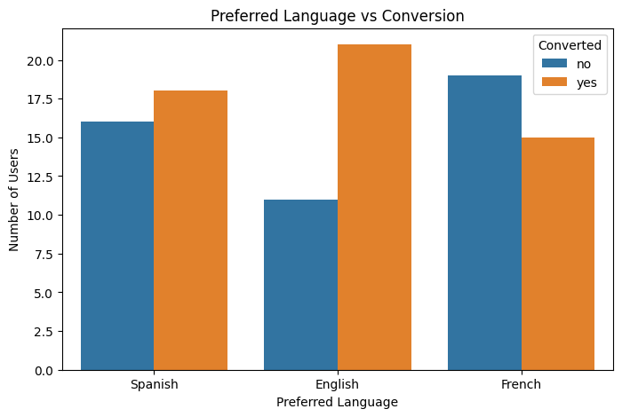

| converted language_preferred | no | yes |
| --- | --- | --- |
| English | 11 | 21 |
| French | 19 | 15 |
| Spanish | 16 | 18 |

```python
plt.figure(figsize=(8,5))
sns.countplot(data=df, x="language_preferred", hue="converted")
plt.title("Preferred Language vs Conversion")
plt.xlabel("Preferred Language")
plt.ylabel("Number of Users")
plt.legend(title="Converted")
plt.show()

# Contingency table of counts
pd.crosstab(df["language_preferred"], df["converted"])
```

**Observation:**

Conversion rates vary across languages — English 65.6%, Spanish 52.9%, French 44.1% — which might suggest an association between language and conversion. However, the differences are moderate and the groups are small ( Approx 34 each), so a formal test is needed to determine whether conversion genuinely depends on language.

### Formulate the hypotheses

The objective is to determine whether the conversion status is associated with the preferred language of the users.

H0 (Null Hypothesis) The converted status is independent of the preferred language.

In other words, there is no significant association between a user's preferred language and their subscription status.

H1 (Alternative Hypothesis)

The converted status depends on the preferred language.

In other words, there is a significant association between a user's preferred language and their subscription status.

### Test Selection

- The objective is to determine whether there is a significant association between preferred language and conversion status.Since both variables are categorical:Preferred Language has 3 categories (English, French, and Spanish). Converted has 2 categories (Yes and No).
- Therefore, the Chi-Square Test of Independence is the appropriate statistical test to determine whether conversion status depends on the user's preferred language.

### Check the assumptions for Chi Square test of independence

- Categorical Variables: Both language_preferred and converted are categorical variables.
- Independent Observations: Each user appears only once in the dataset, and the observations are independent.
- Expected Cell Frequency: The expected frequency in each cell of the contingency table should be at least 5. This assumption will be verified using the expected frequencies returned by the chi-square test.

Since these assumptions are satisfied, the Chi-Square Test of Independence can be used to test the association between preferred language and conversion status.

### Data Preparation

```python
# Build the contingency table of observed counts
contingency_table = pd.crosstab(df["language_preferred"], df["converted"])
print(contingency_table)
```

```
converted           no  yes
language_preferred
English             11   21
French              19   15
Spanish             16   18
```

### Calculate P Value

```python
from scipy.stats import chi2_contingency

chi2_stat, p_value, dof, expected = chi2_contingency(contingency_table)

print("Chi-square statistic =", round(chi2_stat, 4))
print("p-value =", round(p_value, 8))
print("Degrees of freedom =", dof)
print("\nExpected frequencies:\n", expected)
```

```
Chi-square statistic = 3.093
p-value = 0.21298887
Degrees of freedom = 2

Expected frequencies:
 [[14.72 17.28]
 [15.64 18.36]
 [15.64 18.36]]
```

### Inference

```python
alpha = 0.05

if p_value < alpha:
    print(f"As the p-value {p_value} is less than the level of significance {alpha}, we reject the null hypothesis.")
else:
    print(f"As the p-value {p_value} is greater than the level of significance {alpha}, we fail to reject the null hypothesis.")
```

```
As the p-value 0.2129888748754345 is greater than the level of significance 0.05, we fail to reject the null hypothesis.
```

### Conclusion

- The chi-square statistic is 3.093, with 2 degrees of freedom and a p-value of 0.2130.
- Since the p-value (0.213) is greater than the level of significance (0.05), we fail to reject the null hypothesis.
- We do not have sufficient statistical evidence at a 5% significance level to conclude that converted status depends on the preferred language. In other words, conversion appears to be independent of language.

## Q4 Is the mean time spent on the new page same for the different language users?

### Visual Analysis

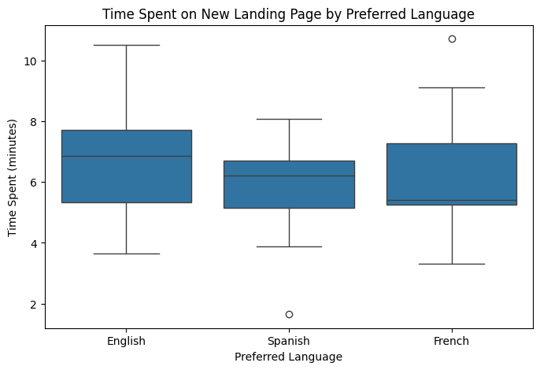

| language_preferred | count | mean | std | min | 25% | 50% | 75% | max |
| --- | --- | --- | --- | --- | --- | --- | --- | --- |
| English | 16.0 | 6.663750 | 1.984150 | 3.65 | 5.3275 | 6.865 | 7.7125 | 10.50 |
| French | 17.0 | 6.196471 | 1.933394 | 3.30 | 5.2500 | 5.420 | 7.2700 | 10.71 |
| Spanish | 17.0 | 5.835294 | 1.525656 | 1.65 | 5.1500 | 6.200 | 6.7000 | 8.08 |

```python
# Filter to new-page users only
new_page = df[df["landing_page"] == "new"]

plt.figure(figsize=(8,5))
sns.boxplot(data=new_page, x="language_preferred", y="time_spent_on_the_page")
plt.title("Time Spent on New Landing Page by Preferred Language")
plt.xlabel("Preferred Language")
plt.ylabel("Time Spent (minutes)")
plt.show()

new_page.groupby("language_preferred")["time_spent_on_the_page"].describe()
```

Observation: Mean time on the new page is similar across languages — English 6.66, French 6.20, Spanish 5.84 minutes — with heavily overlapping boxes. No group stands clearly apart, suggesting the means may be equal. A formal test will confirm.

### Formulate the hypotheses

Let u1, u2, u3 = mean time spent on the new page for English, French, and Spanish users respectively.

H₀: u1 = u2 = u3 (the mean time spent on the new page is the same across all three language groups)

H₁: At least one language group's mean time spent is different from the others.

### Select the appropriate test

A One-Way ANOVA is appropriate because:

- The response variable, time_spent_on_the_page, is continuous.
- The explanatory variable, language_preferred, is categorical with three independent groups (English, French, and Spanish).
- The objective is to compare the mean time spent across more than two independent groups.

### Checking the Assumptions for ANOVA test

Before performing the One-Way ANOVA, the following assumptions should be verified:

- Independent Observations: Each user appears only once in the dataset and belongs to only one preferred language group. Therefore, the observations are independent.
- Normality: The distribution of time spent within each language group should be approximately normal. This assumption will be verified using the Shapiro-Wilk test.
- Homogeneity of Variances: The population variances of the three language groups should be approximately equal. This assumption will be verified using Levene's test.

The results of these assumption tests are presented below before performing the One-Way ANOVA.

### Data collection and preparation

```python
# Time spent on the new page, split by language
time_english = new_page[new_page["language_preferred"] == "English"]["time_spent_on_the_page"]
time_french  = new_page[new_page["language_preferred"] == "French"]["time_spent_on_the_page"]
time_spanish = new_page[new_page["language_preferred"] == "Spanish"]["time_spent_on_the_page"]

print("English - n:", len(time_english), "mean:", round(time_english.mean(), 2))
print("French  - n:", len(time_french),  "mean:", round(time_french.mean(), 2))
print("Spanish - n:", len(time_spanish), "mean:", round(time_spanish.mean(), 2))
```

```
English - n: 16 mean: 6.66
French  - n: 17 mean: 6.2
Spanish - n: 17 mean: 5.84
```

### Assumption 1 — Normality (Shapiro-Wilk's test)

H0: The time spent data for each language group follows a normal distribution.

H1: The time spent data for at least one language group does not follow a normal distribution.

```python
from scipy.stats import shapiro

print("English:", shapiro(time_english))
print("French :", shapiro(time_french))
print("Spanish:", shapiro(time_spanish))
```

```
English: ShapiroResult(statistic=np.float64(0.9731259556930821), pvalue=np.float64(0.8863443479691289))
French : ShapiroResult(statistic=np.float64(0.9402675518653835), pvalue=np.float64(0.32137149516853786))
Spanish: ShapiroResult(statistic=np.float64(0.9072975412348289), pvalue=np.float64(0.09006862258526895))
```

**Conclusion**

Since the p-values for the English (0.8863), French (0.3214), and Spanish (0.0901) groups are all greater than the significance level of 0.05, we fail to reject the null hypothesis for each group.There is insufficient evidence to conclude that the data deviate from a normal distribution. Therefore, the normality assumption is satisfied.

## Assumption 2 — Homogeneity of variances (Levene's test)

H0: The population variances of time spent are equal across the English, French, and Spanish language groups.

H1: At least one language group has a different population variance.

```python
from scipy.stats import levene

statistic, p_value = levene(time_english, time_french, time_spanish)
print("The p-value is", p_value)
```

```
The p-value is 0.46711357711340173
```

**Conclusion:**

The p-value from Levene's test is 0.4671, which is greater than the significance level of 0.05. Therefore, we fail to reject the null hypothesis.There is insufficient evidence to conclude that the variances differ across the language groups. Hence, the homogeneity of variances assumption is satisfied.

### Calculating P value

```python
from scipy.stats import f_oneway

test_stat, p_value = f_oneway(time_english, time_french, time_spanish)

print("Test statistic =", round(test_stat, 4))
print("p-value =", round(p_value, 8))
```

```
Test statistic = 0.8544
p-value = 0.43204139
```

### Inference

```python
alpha = 0.05

if p_value < alpha:
    print(f"As the p-value {p_value} is less than the level of significance {alpha}, we reject the null hypothesis.")
else:
    print(f"As the p-value {p_value} is greater than the level of significance {alpha}, we fail to reject the null hypothesis.")
```

```
As the p-value 0.43204138694325955 is greater than the level of significance 0.05, we fail to reject the null hypothesis.
```

### Conclusion

- The test statistic is 0.8544 and the p-value is 0.4320.
- Since the p-value (0.432) is greater than the level of significance (0.05), we fail to reject the null hypothesis.
- We do not have sufficient statistical evidence at a 5% significance level to conclude that the mean time spent on the new page differs across the three language groups. The mean time spent appears to be the same regardless of preferred language.

### Business Implication

The new landing page holds users' attention for a similar amount of time whether they prefer English, French, or Spanish (means of 6.66, 6.20, and 5.84 minutes respectively). This indicates the new design is equally engaging across all language groups, so E-news Express does not need to create language-specific versions of the page to sustain user engagement.

## Conclusion and Business Recommendations

## Summary of statistical findings

Four hypothesis tests were performed at a 5% significance level to evaluate the effectiveness of the new landing page.

- Q1 Do users spend more time on the new landing page than the old landing page?
  - Independent two-sample t-test (p = 0.00014): Reject the null hypothesis. Users spend significantly more time on the new landing page than on the old landing page.
- Q2 Is the conversion rate of the new landing page greater than that of the old landing page?
  - Two-proportion Z-test (p = 0.008): Reject the null hypothesis. The new landing page has a significantly higher conversion rate.
- Q3 Does conversion status depend on preferred language?
  - Chi-Square Test of Independence (p = 0.213): Fail to reject the null hypothesis. There is no statistically significant association between preferred language and conversion status.
- Q4 – Is the mean time spent on the new landing page the same across different language groups?
  - One-Way ANOVA (p = 0.432): Fail to reject the null hypothesis. There is no statistically significant difference in the mean time spent among the English, French, and Spanish language groups.

### Key conclusions

- The new landing page significantly improves user engagement. Users spend an average of 6.22 minutes on the new page compared to 4.53 minutes on the old page, representing an increase of approximately 37%.
- The new landing page also significantly improves subscriber conversion. The conversion rate increased from 42% on the old landing page to 66% on the new landing page, an improvement of 24 percentage points.
- Preferred language does not have a statistically significant impact on conversion. Although English-speaking users exhibited a higher conversion rate in the sample, the observed differences were not statistically significant.
- Preferred language also does not have a statistically significant impact on user engagement. The mean time spent on the new landing page is comparable across English, French, and Spanish users.

## Business recommendations

1. Roll out the new landing page to all users. The evidence is strong and consistent on the two metrics that matter most — engagement and conversion — so E-news Express should replace the old page with the new one across the board.
2. Do not invest in language-specific versions of the page. Since neither conversion nor time spent depends on preferred language, building and maintaining separate pages per language would add cost without a measurable return. The single new design serves all language groups equally well.
3. Keep the content strategy that drives engagement. The new page's improved outline and more relevant content appear to be what hold users' attention longer and lead to more subscriptions. Future design iterations should preserve and build on these strengths.
4. Continue Monitoring Performance After Rollout Although the experimental results are statistically significant, the study was conducted on a sample of 100 users. After deploying the new landing page, E-News Express should continue monitoring engagement and conversion metrics on a larger user base to ensure that the observed improvements are sustained under real-world conditions
5. Consider further experiments to optimize further. A/B testing has proven valuable here. The company could continue testing specific elements — headlines, layout, calls-to-action, recommended-content placement — to keep improving conversion beyond the gains already achieved.

## Final Conclusion

The statistical analysis provides strong evidence that the new landing page is more effective than the existing page. It significantly increases both user engagement and subscription conversion while delivering a consistent experience across different language groups. Based on these findings, E-News Express should adopt the new landing page as the default version and continue monitoring its performance while using future A/B tests to further optimize the user experience.